# Anomaly Detection IP

# Defining the Question?

## Specifying the Question

You are a Data analyst at Carrefour Kenya and are currently undertaking a project that will inform the marketing department on the most relevant marketing strategies that will result in the highest no. of sales (total price including tax)

Perform Anomaly detection on the sales dataset

## Defining the metrics of success

Perform data cleaning, Exploratory data analysis and Anomaly detection effectively in R

## Understanding the Context

Anomaly detection is collection of techniques designed to identify unusual data points. It helps identify unexpected data points in datasets.There are many applications of anomaly detections such as fraud and intrusion detection, system health monitoring and ecosystem disturbance monitoring. In our case we will be using anomaly detection to detect fraud.

## Recording the Experimental Design

- Reading the Data
- Checking the Data
- Tidying the Data
- Exploratory Data Analysis
- Perform Anomaly Detection

## Data Relevance

The dataset provided was relevant for the objective we set for our project.

# Reading the Dataset

```r
# Loading the Dataset
sf = read.csv('Supermarket_Sales_Forecasting - Sales.csv')
```

# Checking the Dataset

```r
# Checking the shape of the dataset
dim(sf)
```

```
## [1] 1000    2
```

The dataset contains 1000 rows and 2 columns.

```r
# Checking the class of our dataset
class(sf)
```

```
## [1] "data.frame"
```

```r
# Previewing the top of the Dataset
head(sf)
```

```
##        Date    Sales
## 1  1/5/2019 548.9715
## 2  3/8/2019  80.2200
## 3  3/3/2019 340.5255
## 4 1/27/2019 489.0480
## 5  2/8/2019 634.3785
## 6 3/25/2019 627.6165
```

```r
# Previewing the bottom of the Dataset
tail(sf)
```

```
##           Date     Sales
## 995  2/18/2019   63.9975
## 996  1/29/2019   42.3675
## 997   3/2/2019 1022.4900
## 998   2/9/2019   33.4320
## 999  2/22/2019   69.1110
## 1000 2/18/2019  649.2990
```

```r
# Checking the Datatypes of the columns
str(sf)
```

```
## 'data.frame':    1000 obs. of  2 variables:
##  $ Date : chr  "1/5/2019" "3/8/2019" "3/3/2019" "1/27/2019" ...
##  $ Sales: num  549 80.2 340.5 489 634.4 ...
```

The dataset contains 1 column of datatype num and 1 column of datatype character

```r
# Checking for Duplicates
anyDuplicated(sf)
```

```
## [1] 0
```

There were no duplicates in our dataset.

# Tidying the Dataset

## Missing values

```r
# Checking for missing values
colSums(is.na(sf))
```

```
##  Date Sales
##     0     0
```

## Outliers

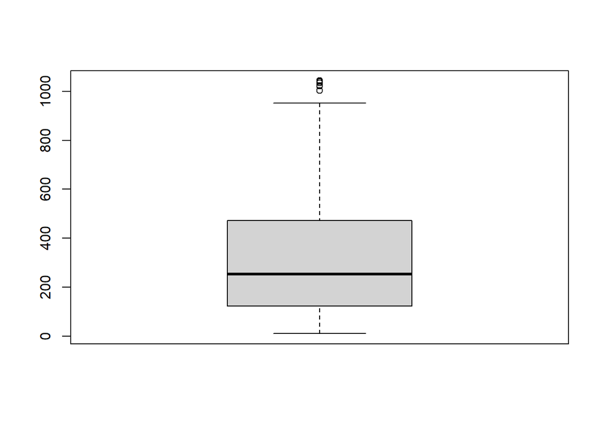

```r
# Checking for Outliers in the sales column
boxplot(sf$Sales)
```

```r
# Checking the list of Outliers in the Sales column
boxplot.stats(sf$Sales)$out
```

```
## [1] 1003.590 1039.290 1042.650 1002.120 1020.705 1034.460 1023.750 1022.385
## [9] 1022.490
```

# Exploratory Data Analysis

### Mean

```r
mean(sf$Sales)
```

```
## [1] 322.9667
```

### Median

```r
median(sf$Sales)
```

```
## [1] 253.848
```

### Maximum

```r
max(sf$Sales)
```

```
## [1] 1042.65
```

### Minimum

```r
min(sf$Sales)
```

```
## [1] 10.6785
```

### Range

```r
range(sf$Sales)
```

```
## [1]   10.6785 1042.6500
```

### Quantile

```r
quantile(sf$Sales)
```

```
##        0%       25%       50%       75%      100%
##   10.6785  124.4224  253.8480  471.3502 1042.6500
```

### Interquantile Range

```r
IQR(sf$Sales)
```

```
## [1] 346.9279
```

### Variance

```r
var(sf$Sales)
```

```
## [1] 60459.6
```

### Standard Deviation

```r
sd(sf$Sales)
```

```
## [1] 245.8853
```

### Skewness

```r
library(e1071)
skewness(sf$Sales)
```

```
## [1] 0.8898939
```

### Kurtosis

```r
kurtosis(sf$Sales)
```

```
## [1] -0.09329206
```

### Histogram

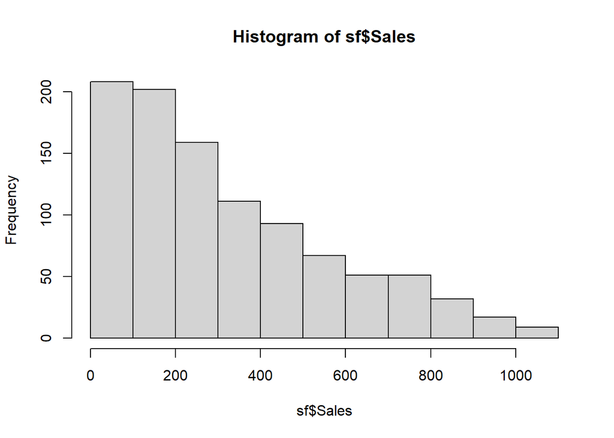

```r
# Plotting the histogram of sales
hist(sf$Sales)
```

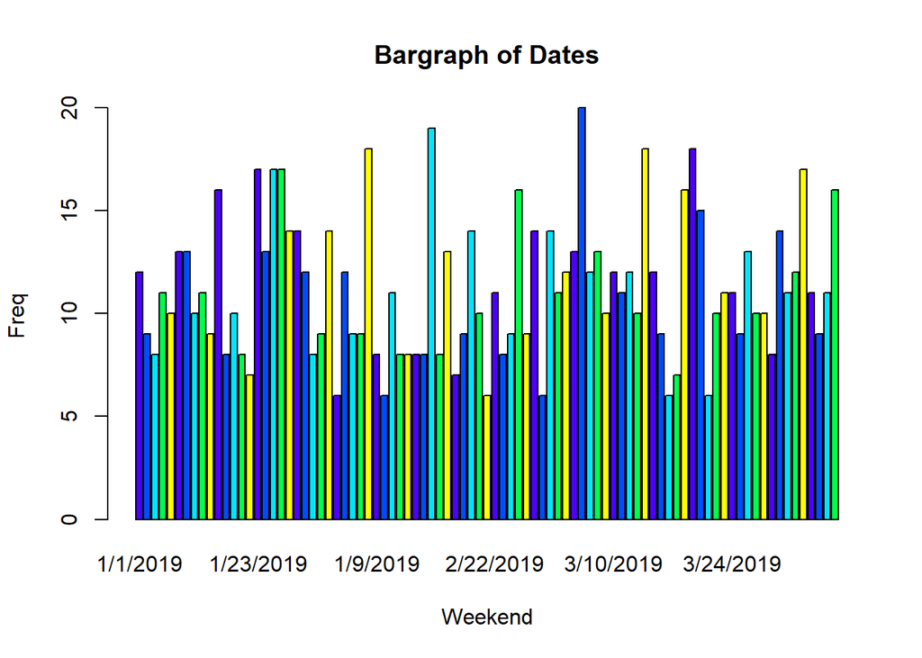

```r
# Plotting barplot of Dates
barplot(table(sf$Date),
main = "Bargraph of Dates",
xlab = "Weekend",
ylab = "Freq",
col = topo.colors(5),
horiz = FALSE)
```

# Implementing the Solution

## Anomaly Detection

```r
# Load tidyverse and anomalize libraries
#
library(tidyverse)
library(anomalize)
# Checking the datatype of Date column
class(sf$Date)
```

```
## [1] "character"
```

```r
# Changing the Date column from character to date format
library(lubridate)
sf$Date <- as.Date(sf$Date, format="%m/%d/%Y")
```

```r
# Ordering the dataframe according to the dates
sf1 <- sf[order(sf$Date),]
```

```r
# Previewing the new dataframe
head(sf1)
```

```
##           Date   Sales
## 18  2019-01-01 457.443
## 246 2019-01-01 399.756
## 451 2019-01-01 470.673
## 485 2019-01-01 388.290
## 497 2019-01-01 132.762
## 524 2019-01-01 132.027
```

```r
# Checking the datatype of Date column
class(sf1$Date)
```

```
## [1] "Date"
```

```r
# Changing the dataset from dataframe format to tibble
sf_tbl = as_tibble(sf1)
head(sf_tbl)
```

```
## # A tibble: 6 x 2
##   Date       Sales
##   <date>     <dbl>
## 1 2019-01-01  457.
## 2 2019-01-01  400.
## 3 2019-01-01  471.
## 4 2019-01-01  388.
## 5 2019-01-01  133.
## 6 2019-01-01  132.
```

```
## Converting from tbl_df to tbl_time.
## Auto-index message: index = Date
```

```
## frequency = 7 days
```

```
## trend = 30 days
```

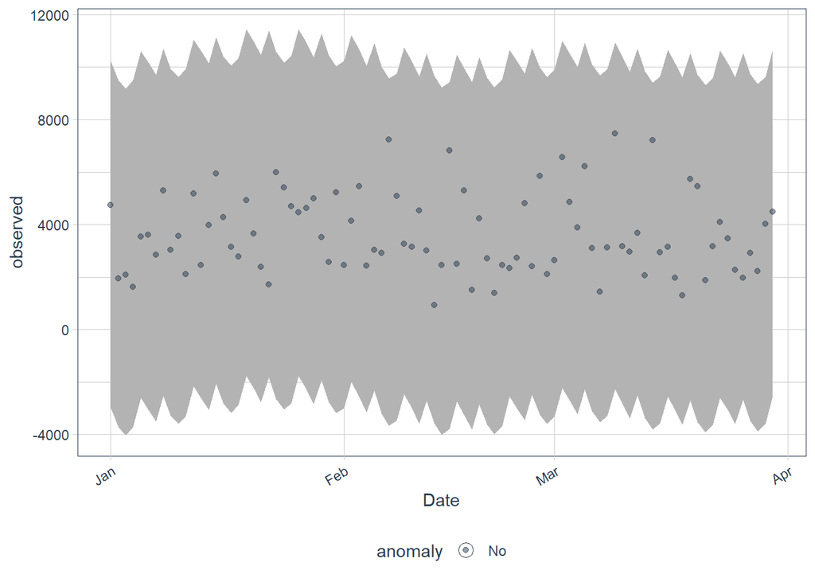

```r
# Detecting the anomalies and plotting them.
sf_tbl %>%
  group_by(Date) %>%
  summarise(Sales = sum(Sales)) %>%
  time_decompose(Sales) %>%
  anomalize(remainder) %>%
  time_recompose() %>%
  plot_anomalies(time_recomposed = TRUE, ncol = 3, alpha_dots = 0.5)
```

There were no anomalies detected from the sales throughout the period the sales were recorded. Since there were no anomalies fraud did not take place in the sales.